# Massachusetts Automobile Claims

Instructor: Edward (Jed) Frees

16 November 2024

# Introduction

We investigate frequency-severity modeling using an insurance automobile claims dataset studied in Ferreira and Minikel (2010, 2012). These data, made public by the Massachusetts Executive Office of Energy and Environmental Affairs (EOEEA), summarizes automobile insurance experience from the state of Massachusetts in year 2006. The dataset consists of approximately 3.25 million policies representing over half a billion dollars of claims.

Because the dataset represents experience from several insurance carriers, it is not surprising that the amount of policyholder information is less than typically used by large carriers that employ advanced analytic techniques. Nonetheless, we do have basic ratemaking information that is common to all carriers, including primary driver characteristics and territory groupings. At the vehicle level, we also have mileage driven in a year, the focus of the Ferreira and Minikel study.

## Data and Summary Statistics

From the Ferreira and Minikel (2010, 2012) data, we drew a random sample of 100,000 policyholders for our analysis. With the following code, you will see after importing the data and looking it over, many values of “TotLoss” were negative. We followed the recommendation of Ferreira and Minikel and forced all losses of less than 50 to be equal to 0.

##### **R Code to Bring in Data**

```r
# R - code to bring in the data, modify it, and produce Table 1
CDatasample <- read.table(file="http://instruction.bus.wisc.edu/jfrees/jfreesbooks/PredictiveModelingVol1/files/chapter-6/FreqSevMassAutoInSample.csv", header=TRUE, sep = ",")
#summary(CDatasample)
CDatasample$TotLoss[CDatasample$TotLoss<50] <- 0
CDatasample$ClaimNum <- CDatasample$ClaimNum*(CDatasample$TotLoss>0)

summary(CDatasample)
```

```
   X               pol_id            vin                class4
```

Min. : 14 Min. : 111 Length:100000 Min. :1101  
1st Qu.: 908490 1st Qu.: 835564 Class :character 1st Qu.:1101  
Median :1805497 Median :1667445 Mode :character Median :1101  
Mean :1802920 Mean :1671713 Mean :1132  
3rd Qu.:2701108 3rd Qu.:2507016 3rd Qu.:1152  
Max. :3599557 Max. :3346256 Max. :1428

```
prem_twn       poleffdte        lasttxdte         startd
```

Min. : 2.0 Min. :200601 Min. :200601 Length:100000  
1st Qu.:300.0 1st Qu.:200603 1st Qu.:200604 Class :character  
Median :603.0 Median :200606 Median :200608 Mode :character  
Mean :501.4 Mean :200606 Mean :200622  
3rd Qu.:715.0 3rd Qu.:200609 3rd Qu.:200611  
Max. :981.0 Max. :200612 Max. :200712

enddate trank ecode ann_miles  
Length:100000 Min. : 1.00 Min. : 0.000 Min. : 1  
Class :character 1st Qu.: 1.00 1st Qu.: 0.000 1st Qu.: 6726  
Mode :character Median : 1.00 Median : 0.000 Median :10728  
Mean : 1.26 Mean : 2.894 Mean :11858  
3rd Qu.: 1.00 3rd Qu.: 0.000 3rd Qu.:15475  
Max. :10.00 Max. :24.000 Max. :99726  
NA’s :9869  
days_overlap Rateclass town_name tgroup  
Min. : -1.0 Min. :1.000 Length:100000 Min. :1.000  
1st Qu.:109.0 1st Qu.:1.000 Class :character 1st Qu.:2.000  
Median :246.0 Median :1.000 Mode :character Median :4.000  
Mean :213.7 Mean :1.526 Mean :3.373  
3rd Qu.:331.0 3rd Qu.:1.000 3rd Qu.:5.000  
Max. :396.0 Max. :9.000 Max. :6.000

rateclassdescrip cgroup losspaid1 lossreserve1  
Length:100000 Length:100000 Min. :-1338.00 Min. : 0.00  
Class :character Class :character 1st Qu.: 0.00 1st Qu.: 0.00  
Mode :character Mode :character Median : 0.00 Median : 0.00  
Mean : 88.56 Mean : 12.91  
3rd Qu.: 0.00 3rd Qu.: 0.00  
Max. :25000.00 Max. :25000.00

losspaid5 lossreserve5 tcount rcount  
Min. :-3618.00 Min. : 0.0 Min. : 0.00000 Min. :0.00000  
1st Qu.: 0.00 1st Qu.: 0.0 1st Qu.: 0.00000 1st Qu.:0.00000  
Median : 0.00 Median : 0.0 Median : 0.00000 Median :0.00000  
Mean : 10.42 Mean : 0.8 Mean : 0.09733 Mean :0.00266  
3rd Qu.: 0.00 3rd Qu.: 0.0 3rd Qu.: 0.00000 3rd Qu.:0.00000  
Max. :24140.00 Max. :9951.0 Max. :22.00000 Max. :6.00000

```
 clm_id           accdtdte           adate               key
```

Min. : 986 Min. :20060101 Length:100000 Length:100000  
1st Qu.:1103383 1st Qu.:20060831 Class :character Class :character  
Median :2229265 Median :20061212 Mode :character Mode :character  
Mean :2276087 Mean :20065147  
3rd Qu.:3420304 3rd Qu.:20070326  
Max. :4800621 Max. :20071207  
NA’s :95736 NA’s :95736  
TotLoss ClaimNum earnexpo select  
Min. : 0.0 Min. :0.00000 Min. :0.08333 Min. :1.040e-07  
1st Qu.: 0.0 1st Qu.:0.00000 1st Qu.:0.91667 1st Qu.:6.929e-03  
Median : 0.0 Median :0.00000 Median :1.00000 Median :1.382e-02  
Mean : 127.5 Mean :0.04315 Mean :0.87041 Mean :1.384e-02  
3rd Qu.: 0.0 3rd Qu.:0.00000 3rd Qu.:1.00000 3rd Qu.:2.078e-02  
Max. :52699.0 Max. :3.00000 Max. :3.00000 Max. :2.767e-02

```r
Table1 <- with(CDatasample, table(cgroup, tgroup, useNA = "ifany"))
```

Table 1: **Number of Policies by Rating Group and Territory**

|  | Terr 1 | Terr 2 | Terr 3 | Terr 4 | Terr 5 | Terr 6 |
| --- | --- | --- | --- | --- | --- | --- |
| A | 13905 | 14603 | 8600 | 15609 | 14722 | 9177 |
| B | 293 | 268 | 153 | 276 | 183 | 96 |
| I | 706 | 685 | 415 | 627 | 549 | 471 |
| M | 700 | 700 | 433 | 830 | 814 | 713 |
| S | 2806 | 3104 | 1644 | 2958 | 2653 | 1307 |

The code also creates a table that shows the distribution of number of policies by rating group and territory. The distribution of policies is reasonably level across territories. In contrast, the distribution by rating group is more uneven; for example, over three quarters of the policies are from the “Adult” group. The sparsest cell is business drivers in territory 6; the most heavily populated cell is territory 4 adult drivers.

Table 2 shows that the average claim number is 4.3%. Specifically, for the 100,000 policies, there were 95,875 that had zero claims, 3,942 that had one claim, 176 that had two claims, and 7 that had three claims. The table also reports important difference by rating group, where the average number of losses for inexperienced youthful drivers are about 2.5 times greater than adult drivers.

Table 2 also summarizes information on the earned exposure, defined here as the amount of time that the policy was in force in the study, and annual mileage. Annual mileage was estimated by Ferreira and Minikel (2010,2012) based on Massachusetts’ Commonwealth’s Registry of Motor Vehicles mandatory annual safety checks, combined with automobile information from the vehicle identification number (commonly known using the acronym VIN). Interestingly, Table 2 shows that only about 90% of our data possess valid information about the number of miles driven, so that about 10% are missing.

Here is the **R** code used to produce Tables 2 and 3.

##### **R Code for Tables 2 and 3**

```r
# R - code to produce Tables 2 and 3

library(Hmisc)
t21 <- summarize(CDatasample[, "TotLoss"],CDatasample[, "cgroup"], length )
t22 <- summarize(CDatasample[, "TotLoss"],CDatasample[, "cgroup"], mean )
t23 <- summarize(CDatasample[, "ClaimNum"],CDatasample[, "cgroup"], mean )
t24 <- summarize(CDatasample[, "earnexpo"],CDatasample[, "cgroup"], mean )
t25 <- summarize(CDatasample[, "ann_miles"],CDatasample[, "cgroup"], mean, na.rm = TRUE )
Table2<- cbind(t21,
                  format(round(t22[2], digits = 2), big.mark = ','),
                  round(t23[2], digits = 3),
                  round(t24[2], digits = 3),
                  round(t25[2], digits = 3))
colnames(Table2) <- c("Rating Group",
  "Number", "Total Loss", "Claim Number", "Earned Exposure", "Annual Miles")
#Table2
t31 <- summarize(CDatasample[, "TotLoss"],CDatasample[, "tgroup"], length )
t32 <- summarize(CDatasample[, "TotLoss"],CDatasample[, "tgroup"], mean )
t33 <- summarize(CDatasample[, "ClaimNum"],CDatasample[, "tgroup"], mean )
t34 <- summarize(CDatasample[, "earnexpo"],CDatasample[, "tgroup"], mean )
t35 <- summarize(CDatasample[, "ann_miles"],CDatasample[, "tgroup"], mean, na.rm = TRUE )
Table3<- cbind(t31,
                  format(round(t32[2], digits = 2), big.mark = ','),
                  round(t33[2], digits = 3),
                  round(t34[2], digits = 3),
                  round(t35[2], digits = 3))
colnames(Table3) <- c("Territory","Number", "Total Loss", "Claim Number", "Earned Exposure", "Annual Miles")
#Table3
```

Table 2: **Averages by Rating Group**

| Rating Group | Number | Total Loss | Claim Number | Earned Exposure | Annual Miles |
| --- | --- | --- | --- | --- | --- |
| A | 76616 | 115.95 | 0.040 | 0.871 | 12527.019 |
| B | 1269 | 159.67 | 0.055 | 0.894 | 14405.950 |
| I | 3453 | 354.68 | 0.099 | 0.764 | 12770.241 |
| M | 4190 | 187.27 | 0.065 | 0.800 | 13478.258 |
| S | 14472 | 114.14 | 0.038 | 0.914 | 7611.064 |

Table 3: **Averages by Territory**

| Territory | Number | Total Loss | Claim Number | Earned Exposure | Annual Miles |
| --- | --- | --- | --- | --- | --- |
| 1 | 18410 | 98.24 | 0.032 | 0.882 | 12488.73 |
| 2 | 19360 | 94.02 | 0.036 | 0.876 | 12323.96 |
| 3 | 11245 | 112.21 | 0.037 | 0.870 | 12399.59 |
| 4 | 20300 | 126.70 | 0.044 | 0.875 | 11961.74 |
| 5 | 18921 | 155.62 | 0.051 | 0.866 | 10955.85 |
| 6 | 11764 | 198.95 | 0.066 | 0.842 | 10783.49 |

Table 3 provides similar information but by territory. Here, we see that the average total loss and number of claims for territory 6 is about twice that for territory 1.

There 4,125 (= 100,000 - 95,875) policies with losses. To get a better handle on claim sizes, Figure 1 provides smooth histograms of the loss distribution. The left-hand panel is in the original (dollar) units, indicating a distribution that is right-skewed. The right-hand panel shows the same distribution on a logarithmic scale where we see a more symmetric behavior.

Do our rating factors affect claim size? To get some insights into this question, Figure 2 shows the logarithmic loss distribution by each factor. The left-hand panel shows the distribution by rating group, the right-hand panel shows the distribution by territory. Neither figure suggests that the rating factors have a strong influence on the size distribution.

Here is the **R** code used to Figures 1 and 2.

##### **R Code for Figures 1 and 2**

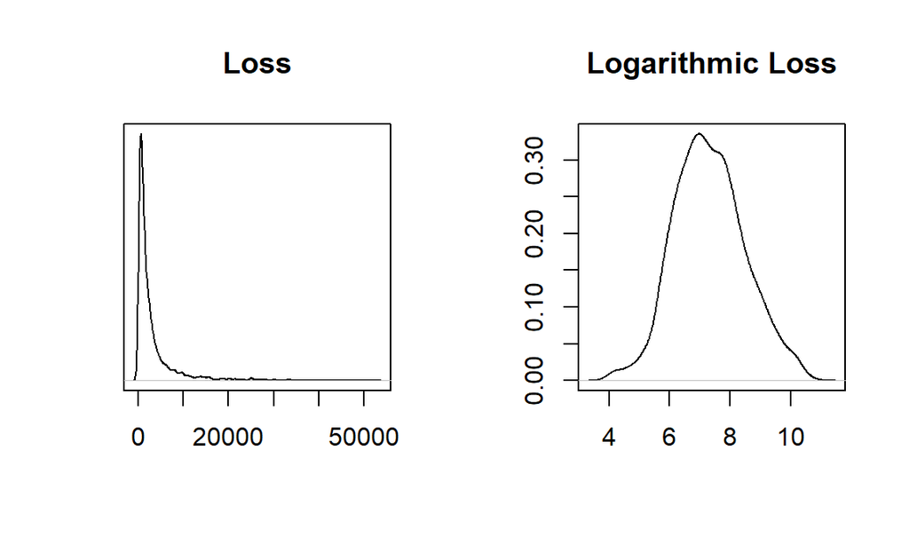

Figure 1: **Loss Distribution.** The left-hand panel shows the distribution of loss, the right-hand panel shows the same distribution but on a (natural) logarithmic scale.

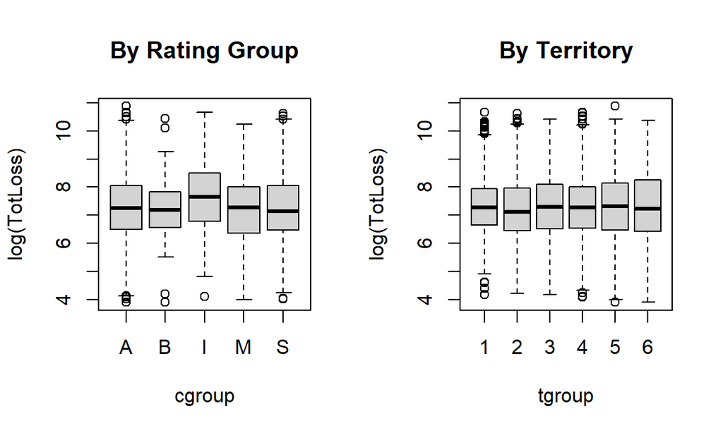

Figure 2: **Logarithmic Loss Distribution by Factor.** The left-hand panel shows the distribution by rating group, the right-hand panel shows the distribution by territory.

```r
#  Distribution of the Claims Severity
SeverityData = subset(CDatasample, TotLoss>0)
#Figure 1
par(mfrow=c(1, 2))
par(yaxt="n",xaxt="s")
plot(density(SeverityData$TotLoss), main="Loss", xlab="", ylab="")
par(yaxt="s")
plot(density(log(SeverityData$TotLoss)), main="Logarithmic Loss", xlab="", ylab="")

#Figure 2
par(mfrow=c(1, 2))
boxplot(log(TotLoss)~cgroup,data=SeverityData,main="By Rating Group")
boxplot(log(TotLoss)~tgroup,data=SeverityData,main="By Territory")
```

# Model Fitting

We report three types of fitted models here: (1) frequency models, (2) a severity model, and (3) a pure premium model.

## Model Fitting - Frequency

Table 4 summarizes the results from two frequency models, Poisson and negative binomial regression models. For both models, we used a logarithmic link with logarithmic exposure as an offset variable. Focussing on the Poisson fit, we see that the $t$-statistics indicate strong statistical significance for several levels of each factor, rating group and territory. Additional tests confirm that they are statistically significant factors. Although not reported in Table 4, we also ran a model that included interactions among terms. The interaction terms were statistically insignificant at the $p-value = 0.303$ level. Hence, we report on the model without interactions, in part because of our desire for simplicity.

We also ran an analysis including annual mileage. This variable turned out to be strongly statistically significant with a $t$-statistic equal to 12.08. However, by including this variable, we also lost 9,869 observations due to missing values in annual mileage. Thus, we treat the potential inclusion of this variable as an interesting follow-up study.

For some audiences, analysts may wish to present the more flexible negative binomial regression model. Table 4 shows that there is little difference in the estimated coefficients for this data set, indicating that the simpler Poisson model is acceptable.

##### **R Code for Table 4**

```r
# R - code to produce Table 4
#  POISSON MODEL
CDatasample$cgroupF <- relevel(factor(CDatasample$cgroup), ref="A")
CDatasample$tgroupF <- relevel(factor(CDatasample$tgroup), ref="6")
ModFreq.3 <- glm(ClaimNum ~ cgroupF+tgroupF, poisson(link=log),
                          offset=log(earnexpo), data=CDatasample)
#summary(ModFreq.3)
stargazer(ModFreq.3, type = "html")
```

|  | *Dependent variable:* |
| --- | --- |
|  | ClaimNum |
| cgroupFB | 0.344*** |
|  | (0.121) |
| cgroupFI | 1.043*** |
|  | (0.057) |
| cgroupFM | 0.541*** |
|  | (0.063) |
| cgroupFS | -0.069 |
|  | (0.046) |
| tgroupF1 | -0.768*** |
|  | (0.055) |
| tgroupF2 | -0.641*** |
|  | (0.052) |
| tgroupF3 | -0.600*** |
|  | (0.061) |
| tgroupF4 | -0.433*** |
|  | (0.049) |
| tgroupF5 | -0.265*** |
|  | (0.048) |
| Constant | -2.636*** |
|  | (0.037) |
| Observations | 100,000 |
| Log Likelihood | -17,326.360 |
| Akaike Inf. Crit. | 34,672.710 |
| *Note:* | p<0.1; p<0.05; p<0.01 |

```r
#  KEEP COEFFICIENTS AND T-STATISTICS
temp1FA <- coefficients(ModFreq.3 )
temp2FA <- temp1FA/sqrt(diag(summary(ModFreq.3 )$cov.scaled))
temp3FA <- cbind(temp1FA,temp2FA)

#  ALTERNATIVE POISSON MODEL WITH INTERACTIONS
ModFreq.4 <- glm(ClaimNum ~ cgroupF+tgroupF+tgroupF:cgroupF,
                 poisson(link=log), offset=log(earnexpo),
                 data=CDatasample)
#summary(ModFreq.4)
stargazer(ModFreq.4, type = "html")
```

|  | *Dependent variable:* |
| --- | --- |
|  | ClaimNum |
| cgroupFB | 0.505 |
|  | (0.319) |
| cgroupFI | 1.089*** |
|  | (0.127) |
| cgroupFM | 0.673*** |
|  | (0.123) |
| cgroupFS | -0.138 |
|  | (0.124) |
| tgroupF1 | -0.748*** |
|  | (0.065) |
| tgroupF2 | -0.613*** |
|  | (0.062) |
| tgroupF3 | -0.670*** |
|  | (0.074) |
| tgroupF4 | -0.433*** |
|  | (0.058) |
| tgroupF5 | -0.221*** |
|  | (0.057) |
| cgroupFB:tgroupF1 | -0.294 |
|  | (0.442) |
| cgroupFI:tgroupF1 | -0.204 |
|  | (0.202) |
| cgroupFM:tgroupF1 | -0.160 |
|  | (0.221) |
| cgroupFS:tgroupF1 | 0.126 |
|  | (0.172) |
| cgroupFB:tgroupF2 | -0.645 |
|  | (0.478) |
| cgroupFI:tgroupF2 | -0.095 |
|  | (0.191) |
| cgroupFM:tgroupF2 | -0.126 |
|  | (0.207) |
| cgroupFS:tgroupF2 | 0.026 |
|  | (0.166) |
| cgroupFB:tgroupF3 | 0.374 |
|  | (0.435) |
| cgroupFI:tgroupF3 | 0.044 |
|  | (0.218) |
| cgroupFM:tgroupF3 | -0.126 |
|  | (0.254) |
| cgroupFS:tgroupF3 | 0.464*** |
|  | (0.180) |
| cgroupFB:tgroupF4 | -0.170 |
|  | (0.407) |
| cgroupFI:tgroupF4 | 0.015 |
|  | (0.180) |
| cgroupFM:tgroupF4 | -0.136 |
|  | (0.189) |
| cgroupFS:tgroupF4 | 0.120 |
|  | (0.159) |
| cgroupFB:tgroupF5 | -0.134 |
|  | (0.424) |
| cgroupFI:tgroupF5 | -0.031 |
|  | (0.180) |
| cgroupFM:tgroupF5 | -0.276 |
|  | (0.188) |
| cgroupFS:tgroupF5 | -0.154 |
|  | (0.163) |
| Constant | -2.647*** |
|  | (0.043) |
| Observations | 100,000 |
| Log Likelihood | -17,315.000 |
| Akaike Inf. Crit. | 34,690.000 |
| *Note:* | p<0.1; p<0.05; p<0.01 |

```r
anova(ModFreq.3,ModFreq.4)
```

Analysis of Deviance Table

Model 1: ClaimNum ~ cgroupF + tgroupF Model 2: ClaimNum ~ cgroupF + tgroupF + tgroupF:cgroupF Resid. Df Resid. Dev Df Deviance 1 99990 26288  
2 99970 26265 20 22.717

```r
anova(ModFreq.4,test="Chisq")
```

Analysis of Deviance Table

Model: poisson, link: log

Response: ClaimNum

Terms added sequentially (first to last)

```
            Df Deviance Resid. Df Resid. Dev Pr(>Chi)
```

NULL 99999 26884  
cgroupF 4 327.34 99995 26557 <2e-16 *tgroupF 5 269.34 99990 26288 <2e-16* cgroupF:tgroupF 20 22.72 99970 26265 0.3029  
— Signif. codes: 0 ‘**’ 0.001 ’**’ 0.01 ’’ 0.05 ‘.’ 0.1 ’ ’ 1

```r
#FIT A NEGATIVE BINOMIAL MODEL;
library(MASS)             # library need to fit negative binomial
ModFreq.5 <- glm.nb(ClaimNum ~ cgroupF+tgroupF+offset(log(earnexpo)),
                   link=log, data=CDatasample)
#summary(ModFreq.5)
stargazer(ModFreq.5, type = "html")
```

|  | *Dependent variable:* |
| --- | --- |
|  | ClaimNum |
| cgroupFB | 0.343*** |
|  | (0.123) |
| cgroupFI | 1.038*** |
|  | (0.059) |
| cgroupFM | 0.539*** |
|  | (0.064) |
| cgroupFS | -0.069 |
|  | (0.047) |
| tgroupF1 | -0.766*** |
|  | (0.056) |
| tgroupF2 | -0.640*** |
|  | (0.053) |
| tgroupF3 | -0.598*** |
|  | (0.062) |
| tgroupF4 | -0.432*** |
|  | (0.050) |
| tgroupF5 | -0.264*** |
|  | (0.049) |
| Constant | -2.639*** |
|  | (0.038) |
| Observations | 100,000 |
| Log Likelihood | -17,315.230 |
| theta | 2.128*** (0.498) |
| Akaike Inf. Crit. | 34,650.450 |
| *Note:* | p<0.1; p<0.05; p<0.01 |

```r
# KEEP COEFFICIENTS AND T-STATISTICS
temp1F <- coefficients(ModFreq.5)
temp2F <- temp1F/sqrt(diag(summary(ModFreq.5 )$cov.scaled))
temp3F <- cbind(temp1F,temp2F)
```

Table 4: **Comparison of Poisson and Negative Binomial Models**

|  | Poisson Estimate | Poisson t-statistic | Neg Bin Estimate | Neg Bin t-statistic |
| --- | --- | --- | --- | --- |
| (Intercept) | -2.636 | -70.921 | -2.639 | -69.671 |
| cgroupFB | 0.344 | 2.846 | 0.343 | 2.790 |
| cgroupFI | 1.043 | 18.271 | 1.038 | 17.638 |
| cgroupFM | 0.541 | 8.578 | 0.539 | 8.383 |
| cgroupFS | -0.069 | -1.493 | -0.069 | -1.477 |
| tgroupF1 | -0.768 | -14.022 | -0.766 | -13.785 |
| tgroupF2 | -0.641 | -12.241 | -0.640 | -12.037 |
| tgroupF3 | -0.600 | -9.867 | -0.598 | -9.704 |
| tgroupF4 | -0.433 | -8.810 | -0.432 | -8.638 |
| tgroupF5 | -0.265 | -5.491 | -0.264 | -5.375 |

## Model Fitting - Severity

##### **R Code for Table 5**

```r
# R - code to produce Table 5

CDatasample$cgroupF <- relevel(factor(CDatasample$cgroup), ref="A")
CDatasample$tgroupF <- relevel(factor(CDatasample$tgroup), ref="6")
#  Claims Severity Modeling
SeverityData <- subset(CDatasample, TotLoss>0)
SeverityGAM2 <- glm(TotLoss/ClaimNum  ~ cgroupF+tgroupF,
                    weights=ClaimNum,
                    Gamma(link=log), data=SeverityData)
#summary(SeverityGAM2)
stargazer(SeverityGAM2, type = "html")
```

|  | *Dependent variable:* |
| --- | --- |
|  | TotLoss/ClaimNum |
| cgroupFB | 0.014 |
|  | (0.189) |
| cgroupFI | 0.222** |
|  | (0.089) |
| cgroupFM | -0.013 |
|  | (0.099) |
| cgroupFS | 0.036 |
|  | (0.072) |
| tgroupF1 | 0.026 |
|  | (0.086) |
| tgroupF2 | -0.137* |
|  | (0.082) |
| tgroupF3 | 0.004 |
|  | (0.095) |
| tgroupF4 | -0.029 |
|  | (0.077) |
| tgroupF5 | 0.019 |
|  | (0.075) |
| Constant | 7.986*** |
|  | (0.058) |
| Observations | 4,125 |
| Log Likelihood | -38,789.290 |
| Akaike Inf. Crit. | 77,598.570 |
| *Note:* | p<0.1; p<0.05; p<0.01 |

```r
anova(SeverityGAM2,test="Chisq")
```

Analysis of Deviance Table

Model: Gamma, link: log

Response: TotLoss/ClaimNum

Terms added sequentially (first to last)

```
    Df Deviance Resid. Df Resid. Dev Pr(>Chi)
```

NULL 4124 5857.6  
cgroupF 4 15.685 4120 5842.0 0.1680 tgroupF 5 12.364 4115 5829.6 0.4058

```r
resids <- residuals(SeverityGAM2,type=c("deviance"))
#hist(resids)
temp1S <- coefficients(SeverityGAM2)
temp2S <- temp1S/sqrt(diag(summary(SeverityGAM2)$cov.scaled))
```

Table 5: **Gamma Regression Models**

|  | temp1S | temp2S |
| --- | --- | --- |
| (Intercept) | 7.986 | 137.335 |
| cgroupFB | 0.014 | 0.076 |
| cgroupFI | 0.222 | 2.492 |
| cgroupFM | -0.013 | -0.131 |
| cgroupFS | 0.036 | 0.500 |
| tgroupF1 | 0.026 | 0.309 |
| tgroupF2 | -0.137 | -1.673 |
| tgroupF3 | 0.004 | 0.041 |
| tgroupF4 | -0.029 | -0.376 |
| tgroupF5 | 0.019 | 0.255 |

## Model Fitting - Pure Premium

As an alternative to the frequency severity approach, we also fit a model using “pure premiums,” total losses, as the dependent variable. Similar to the frequency and severity models, we use a logarithmic link function with the factors rating group and territory. The Tweedie distribution was used. We approximated the Tweedie shape parameter $p$ using profile likelihood and found that the value $p=1.5$ was acceptable. This was the value used in the final estimation.

##### **R Code for Table 6**

```r
# R - code to produce Table \@ref(tab:Table6)

# Tweedie Model
library(tweedie)
library(statmod)
out <- tweedie.profile(CDatasample$TotLoss~1,
                   p.vec=seq(1.1,1.9,length=9),
                   method="interpolation",do.ci=TRUE,
                   do.smooth=TRUE,do.plot=TRUE)
```

1.1 1.2 1.3 1.4 1.5 1.6 1.7 1.8 1.9 ………Done.

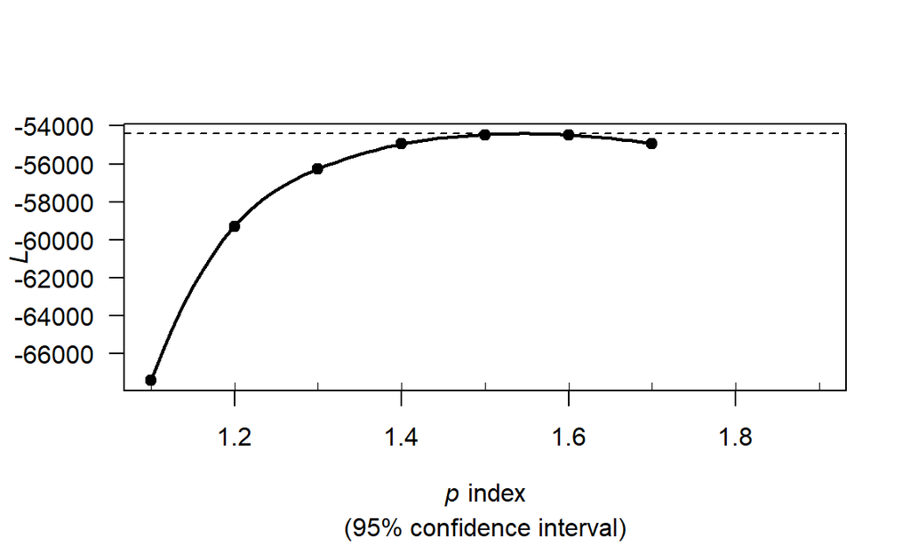

```r
out <- tweedie.profile(TotLoss ~ cgroupF+tgroupF,
                   data=CDatasample,p.vec=seq(1.4,1.6,length=5),
                   method="interpolation",do.ci=TRUE,
                   do.smooth=TRUE,do.plot=TRUE)
```

1.4 1.45 1.5 1.55 1.6 …..Done.

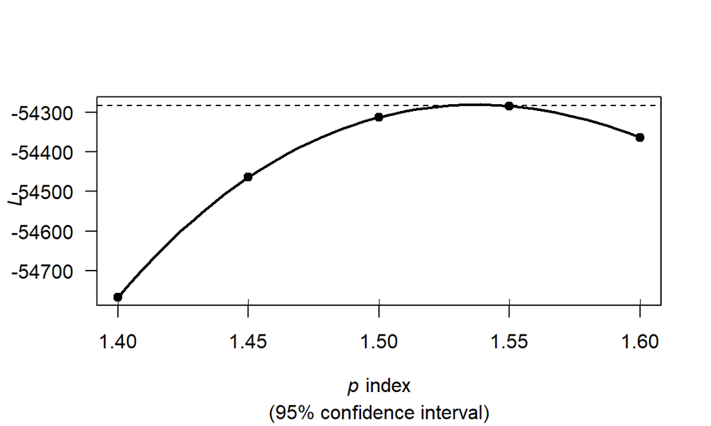

```r
out$p.max;out$phi.max
```

[1] 1.538776 [1] 473.0612

```r
Mod.tweedie <- glm(TotLoss ~ cgroupF+tgroupF,
              data=CDatasample,
              family=tweedie(var.power=out$p.max,link.power=0))
#summary(Mod.tweedie)
stargazer(Mod.tweedie, type = "html")
```

|  | *Dependent variable:* |
| --- | --- |
|  | TotLoss |
| cgroupFB | 0.389 |
|  | (0.250) |
| cgroupFI | 1.130*** |
|  | (0.130) |
| cgroupFM | 0.421*** |
|  | (0.137) |
| cgroupFS | 0.025 |
|  | (0.087) |
| tgroupF1 | -0.686*** |
|  | (0.107) |
| tgroupF2 | -0.734*** |
|  | (0.106) |
| tgroupF3 | -0.549*** |
|  | (0.120) |
| tgroupF4 | -0.409*** |
|  | (0.102) |
| tgroupF5 | -0.210** |
|  | (0.101) |
| Constant | 5.170*** |
|  | (0.080) |
| Observations | 100,000 |
| *Note:* | p<0.1; p<0.05; p<0.01 |

```r
Mod1.tweedie <- glm(TotLoss ~ cgroupF+tgroupF,
               data=CDatasample,
               family=tweedie(var.power=1.5,link.power=0))
#summary(Mod1.tweedie)
stargazer(Mod1.tweedie, type = "html")
```

|  | *Dependent variable:* |
| --- | --- |
|  | TotLoss |
| cgroupFB | 0.388 |
|  | (0.248) |
| cgroupFI | 1.129*** |
|  | (0.127) |
| cgroupFM | 0.423*** |
|  | (0.136) |
| cgroupFS | 0.024 |
|  | (0.087) |
| tgroupF1 | -0.687*** |
|  | (0.106) |
| tgroupF2 | -0.734*** |
|  | (0.106) |
| tgroupF3 | -0.549*** |
|  | (0.119) |
| tgroupF4 | -0.410*** |
|  | (0.101) |
| tgroupF5 | -0.210** |
|  | (0.100) |
| Constant | 5.170*** |
|  | (0.079) |
| Observations | 100,000 |
| *Note:* | p<0.1; p<0.05; p<0.01 |

```r
Mod2.tweedie <- glm(TotLoss ~ cgroupF+tgroupF+offset(log(earnexpo)),
                data=CDatasample,
                family=tweedie(var.power=1.5,link.power=0) )
#summary(Mod2.tweedie)
stargazer(Mod2.tweedie, type = "html")
```

|  | *Dependent variable:* |
| --- | --- |
|  | TotLoss |
| cgroupFB | 0.340 |
|  | (0.267) |
| cgroupFI | 1.283*** |
|  | (0.137) |
| cgroupFM | 0.474*** |
|  | (0.147) |
| cgroupFS | -0.033 |
|  | (0.092) |
| tgroupF1 | -0.743*** |
|  | (0.114) |
| tgroupF2 | -0.782*** |
|  | (0.113) |
| tgroupF3 | -0.552*** |
|  | (0.126) |
| tgroupF4 | -0.480*** |
|  | (0.108) |
| tgroupF5 | -0.269** |
|  | (0.108) |
| Constant | 5.356*** |
|  | (0.084) |
| Observations | 100,000 |
| *Note:* | p<0.1; p<0.05; p<0.01 |

```r
temp1T <- coefficients(Mod2.tweedie)
temp2T <- temp1T/sqrt(diag(summary(Mod2.tweedie)$cov.scaled))
```

Table 6: **Tweedie Regression Model**

|  | Estimate | $t$-statistic |
| --- | --- | --- |
| (Intercept) | 5.356 | 63.471 |
| cgroupFB | 0.340 | 1.277 |
| cgroupFI | 1.283 | 9.389 |
| cgroupFM | 0.474 | 3.221 |
| cgroupFS | -0.033 | -0.358 |
| tgroupF1 | -0.743 | -6.535 |
| tgroupF2 | -0.782 | -6.916 |
| tgroupF3 | -0.552 | -4.368 |
| tgroupF4 | -0.480 | -4.438 |
| tgroupF5 | -0.269 | -2.498 |

# Application: Massachusetts Automobile Claims

## Out-of-Sample Model Comparisons

To compare the frequency-severity and pure premium approaches, we examined a *held-out* validation sample. Specifically, from our original database, we drew a random sample of 100,000 policies and developed the models reported earlier. Then, we drew an (independent) sample of 50,000 policies. You don’t have access to the original data files and thus can not draw the random samples that we did. Nonetheless, you may find the follow **R** code interesting, to see how we did it.

##### **R Code for Independent In- and Out-Samples**

```r
# R code for drawing the independent in-sample and out-of-sample data
ComboData <-  read.csv(choose.files(), header=TRUE);str(ComboData)
length(ComboData$ann_miles[ComboData$ann_miles==-1])  #356,446 obs with mileage missing
nsamp <- length(ComboData$ann_miles) #3,599,649 records
set.seed(123457)
ComboData$select <- runif(nsamp)
ComboData        <- ComboData[order(ComboData$select),]
CDatasample      <- ComboData[1:100000,]
str(CDatasample)
OutDatasample    <- ComboData[100001:150000,]
write.csv(CDatasample, file = "CDatasample1.csv")
write.csv(OutDatasample, file = "OutDatasample.csv")
```

##### **R Code for Figure 3**

[figure not shown]

```r
# R - code to produce Figure 3
OutDatasample <- read.table(file="http://instruction.bus.wisc.edu/jfrees/jfreesbooks/PredictiveModelingVol1/files/chapter-6/FreqSevMassAutoOutSample.csv", header=TRUE, sep = ",")
OutDatasample$TotLoss[OutDatasample$TotLoss<50] <- 0
OutDatasample$ClaimNum <- OutDatasample$ClaimNum*(OutDatasample$TotLoss>0)

RGA <- 1*(OutDatasample$cgroup=="A")
RGB <- 1*(OutDatasample$cgroup=="B")
RGI <- 1*(OutDatasample$cgroup=="I")
RGM <- 1*(OutDatasample$cgroup=="M")
RGS <- 1*(OutDatasample$cgroup=="S")
t1 <- 1*(OutDatasample$tgroup==1)
t2 <- 1*(OutDatasample$tgroup==2)
t3 <- 1*(OutDatasample$tgroup==3)
t4 <- 1*(OutDatasample$tgroup==4)
t5 <- 1*(OutDatasample$tgroup==5)
t6 <- 1*(OutDatasample$tgroup==6)
Xout <- as.matrix(cbind(rep(1,length(OutDatasample$cgroup)),RGB,RGI,RGM,RGS,t1,t2,t3,t4,t5))

ModFreq.coeff  <- c(-2.63630253,0.34417693,1.04343965,0.54125024,-0.06883301,-0.76823395,-0.64125693,-0.59975338,-0.43333458,-0.26509998)
ModSev.coeff   <- c(7.9765427877,0.0424532525,0.2845107148,-0.0269906013,0.0618664973,0.0217031346,-0.1456262957,0.0184503523,-0.0233348614,-0.0002602852)
ModTweed.coeff <- c(5.35593653,0.34031489,1.28297178,0.47387179,-0.03307208,-0.74268966,-0.78193822,-0.55239787,-0.48021351,-0.26879875)
freq1score <- exp(Xout %*% ModFreq.coeff)*OutDatasample$earnexpo
sevscore <- exp(Xout %*% ModSev.coeff)
totscore <- freq1score*sevscore
ppscore <- exp(Xout %*% ModTweed.coeff)*OutDatasample$earnexpo
# par(mfrow=c(1, 2))
# hist(ppscore, main="", xlab="Pure Premium Score")
# plot(ppscore,totscore,ylab="Freq Sever Score", xlab="Pure Premium Score")
```

Here is the **R** code to produce Table 7. To test this out, use the number “ntest” to be something small, like 2500. On my machine, the full run of ntest=50000 takes longer.

##### **R Code for Table 7**

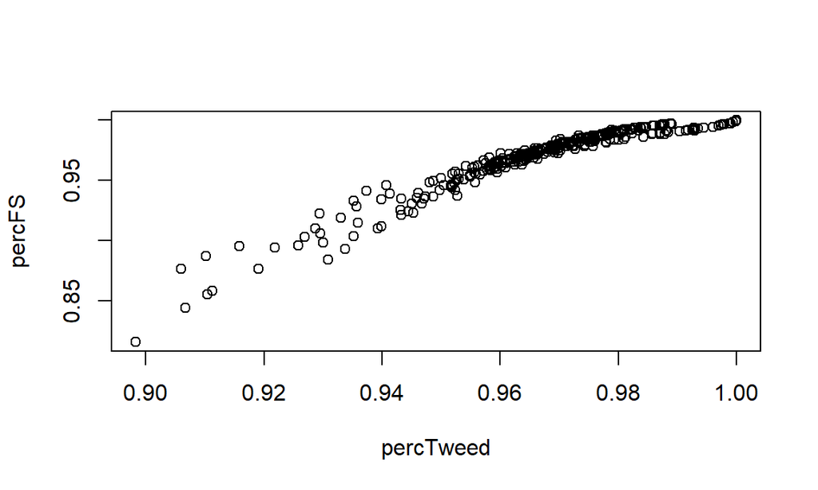

```r
# R - code to produce Table 7
out2phi  <- 515.3381
alpha    <- 1/2.34693
#ntest   <- 50000
ntest    <- 2500
ppscore1 <- ppscore[1:ntest]

mui  <- (freq1score*sevscore)[1:ntest]
p    <- (alpha+2)/(alpha+1)
phii <- (mui^(-p)*freq1score*(sevscore^2/alpha)*(1+alpha))[1:ntest]

yout <- OutDatasample$TotLoss[1:ntest]
library(tweedie)
percTweed <- ptweedie(yout, xi=1.5, mu=ppscore1, phi=out2phi, power=NULL)
percFS    <- ptweedie(yout, xi=p, mu=mui, phi=phii, power=NULL)
plot(percTweed,percFS)
```

```r
quantTWFS <-function(perc){
  t1 <- sum(1*(percTweed<perc))/ntest
  t2 <- sum(1*(percFS<perc))/ntest
  outt <- c(perc,t1,t2)
  t(as.matrix(outt) )
  }
Table7 <- rbind(quantTWFS(0.96),  quantTWFS(0.97),
             quantTWFS(0.98),  quantTWFS(0.985),
             quantTWFS(0.99),  quantTWFS(0.995),
             quantTWFS(0.999) )
```

Table 7: **Out-of-Sample Quantile Performance**

| Percentile | Pure Premium | Frequency Severity |
| --- | --- | --- |
| 0.960 | 0.5144 | 0.4264 |
| 0.970 | 0.8568 | 0.7912 |
| 0.980 | 0.9404 | 0.8644 |
| 0.985 | 0.9712 | 0.9104 |
| 0.990 | 0.9904 | 0.9436 |
| 0.995 | 0.9948 | 0.9792 |
| 0.999 | 0.9972 | 0.9980 |